# fleetEffSim-qc

Lachlan Fox

28/09/2021

# FleetEffSim

First the setup - probably don’t need all these packages but they’re my defaults.

```r
library(readxl)
library(tidyverse)
library(lubridate)
library(scales)
library(janitor)
library(grattantheme)
library(readxl)
library(data.table)
library(devtools)
load_all()
```

```
## ℹ Loading fleeteffSim
```

A typical model run will usually be done by running three functions: - compliance_costs() - benefit_model() - generate_results()

The first function adds technology to vehicles, reducing their emissions for a given cost to meet the targets.

```
## Target reached for year  2024
```

```
## 2024 average emission value is  159.88
```

```
## The average cost increase per vehicle was $ 355.1
```

```
## Moving to next year
```

```
## Target reached for year  2025
```

```
## 2025 average emission value is  148.83
```

```
## The average cost increase per vehicle was $ 589.23
```

```
## Moving to next year
```

```
## Target reached for year  2024
```

```
## 2024 average emission value is  167.45
```

```
## The average cost increase per vehicle was $ 183.6
```

```
## Moving to next year
```

```
## Target reached for year  2025
```

```
## 2025 average emission value is  164.02
```

```
## The average cost increase per vehicle was $ 249.45
```

```
## Moving to next year
```

The second function takes the output of the compliance_costs function to estimate the running costs, petrol use, emissions etc. of the vehicles.

The output of the benefit_model function is used for anything where we want more granular data on the output, as it contains each vehicles emissions/running costs etc. It also includes dead cars (i.e. post 17 years old with 0 km in each year), so need to be careful to exclude them if using this data.

A potential output from this scenario could, for example, be a bar chart comparing the emissions under the bau and target scenarios. I.e.

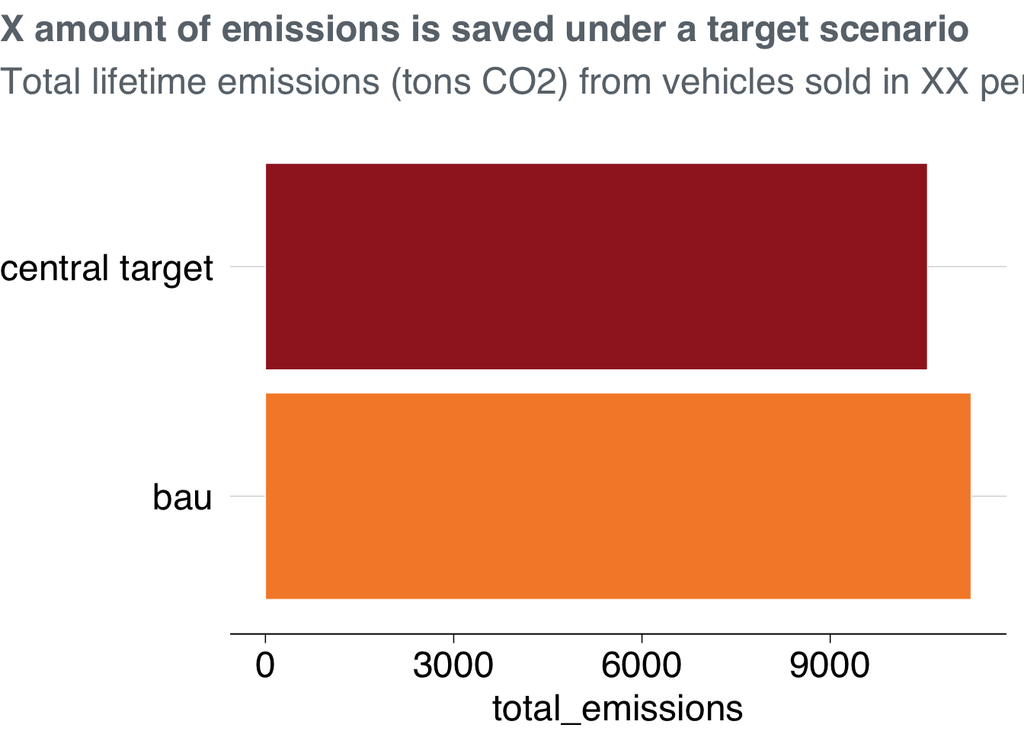

Comparatively, for a high level overview of the results that is summarised, we use the generate_results() function. This compares between the target and bau scenarios to get the additional costs/benefits of the policy.

This output would often be used either to determine a figure for the cost of abatement (i.e. so we can say in the text, this policy has a benefit fo $35 per tonne of carbon abated) or to compare multiple different target scenarios or sensitivity runs. Hard to demonstrate with only one model runs, but I’ve invited you to the overleaf document, where page 20 (fig 3.4) demonstrates this.

The other result of this is to break up the components of the results, for eg:

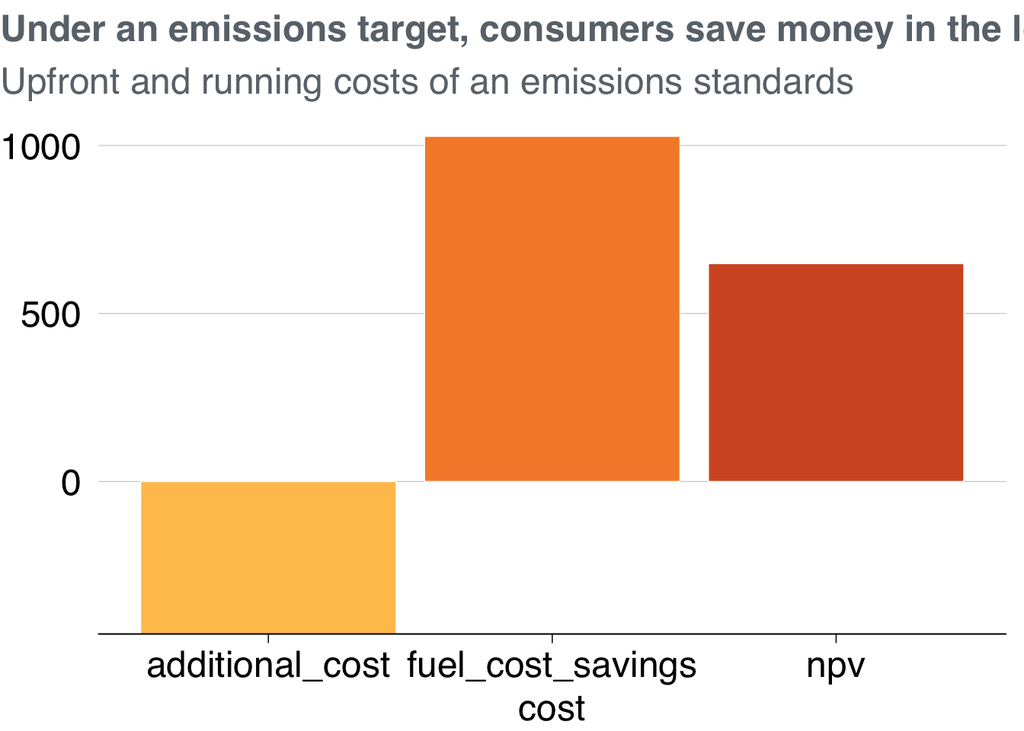

These three steps are all summarised into one function for more general use - fleet_eff_sim(). It does the exact same thing as the above process but only gives out the summary data. Don’t tend to use it lots because it doesn’t let me see the results of each step, but might be helpful for someone else running the model, and good for quick tests of individual scenarios.

```
## Target reached for year  2024
```

```
## 2024 average emission value is  159.88
```

```
## The average cost increase per vehicle was $ 355.1
```

```
## Moving to next year
```

```
## Target reached for year  2025
```

```
## 2025 average emission value is  148.83
```

```
## The average cost increase per vehicle was $ 589.23
```

```
## Moving to next year
```

```
## Target reached for year  2024
```

```
## 2024 average emission value is  167.45
```

```
## The average cost increase per vehicle was $ 183.6
```

```
## Moving to next year
```

```
## Target reached for year  2025
```

```
## 2025 average emission value is  164.02
```

```
## The average cost increase per vehicle was $ 249.45
```

```
## Moving to next year
```